# Analysis of Healthcare Access vs Chronic Disease Burden in the American Southwest

Teresa McCarrell

2026-07-30

### Introduction

Chronic disease burden (diabetes, high blood pressure, and obesity) and preventive care access (health insurance coverage and routine checkups) were examined across counties in five American southwestern states (Arizona, California, New Mexico, Oklahoma, Texas). Data was drawn from the public CDC PLACES County Data release, which provides model-based prevalence estimates for chronic disease and preventive care measures at the county level nationwide, based on 2023 Behavioral Risk Factor Surveillance System (BRFSS) survey data.

This report answers four questions: (1) What does the distribution of chronic disease burden look like across counties in these states? (2) Is there a relationship between preventive care access and chronic disease burden? (3) How does this access-burden relationship vary between states? (4) How do counties associated with major metropolitan areas compare to their rural areas within the same state?

Although this report uses PLACES data as a tool for identifying where disparities in health outcomes and access exist, the CDC advises that PLACES estimates, as model-based small-area predictions, are not intended to be the sole data source for evaluating the effects of specific programs or determining the targets of policy interventions.

### Data & Methods

All records reflect age-adjusted prevalence, allowing valid comparison across counties with differing age structures. Non-parametric methods were used due to non-normal data distributions; Kruskal-Wallis tests with Dunn’s post-hoc pairwise comparisons to determine state-level differences, and Spearman’s rank correlation to evaluate the relationship between access and burden measures.

Counties were manually classified as urban or rural based on inclusion in a state’s principal metropolitan area(s). Ambiguous cases were resolved by cross-referencing county-to-metro assignments (e.g., searching for which counties are considered part of Dallas-Fort Worth). This classification is coarser than a formal designation (e.g., USDA Rural-Urban Continuum Codes). Urban county counts are notably small in Arizona, New Mexico, and Oklahoma (two urban counties each), in comparision to urban county counts in Texas and California. Cmparisons involving urban vs rural counties should be read with sample size in mind (Table 1).

| State | Urban/Rural | County Count |
| --- | --- | --- |
| AZ | Rural | 13 |
| AZ | Urban | 2 |
| CA | Rural | 42 |
| CA | Urban | 16 |
| NM | Rural | 31 |
| NM | Urban | 2 |
| OK | Rural | 75 |
| OK | Urban | 2 |
| TX | Rural | 242 |
| TX | Urban | 12 |

Table 1. County counts by state and urban/rural classification.

### Results

#### #1: What is distribution of chronic disease burden across counties in these states?

State was significantly associated with all five measures examined (Supplementary Table 1), though there was cosiderable variation in the strength of the association. Effect sizes ranged from moderate for diabetes (ε² = 0.14), to large for the remaining four measures. Annual checkup rate showed the strongest state-level association (ε² = 0.73), followed by high blood pressure (ε² = 0.54), uninsured rate (ε² = 0.49), and obesity (ε² = 0.44) (Supplementary Table 2). The comparatively weak association of diabetes with state suggests that other factors, such as the genetic predisposition of the local demographic, may play a larger role in diabetes prevalence than in the other measures studied.

California and Oklahoma emerged as the most consistently divergent pair of states. Of the seven state-measure pairings showing the largest effect sizes (|z| > 10), three involved Oklahoma and California, spanning annual checkups, high blood pressure, and obesity (Table 2). Oklahoma recorded the highest statewide median prevalence of high blood pressure (37.4%) and obesity (40.4%) among the five states, while also recording the highest annual checkup rate (76.2%). California, by contrast, recorded the lowest median prevalence across nearly every measure, including diabetes (10.1%), high blood pressure (29.4%), and obesity (30.4%) (Table 3). Figures 1 and 2 illustrate the dataset-wide measure distributions and state-level patterns directly.

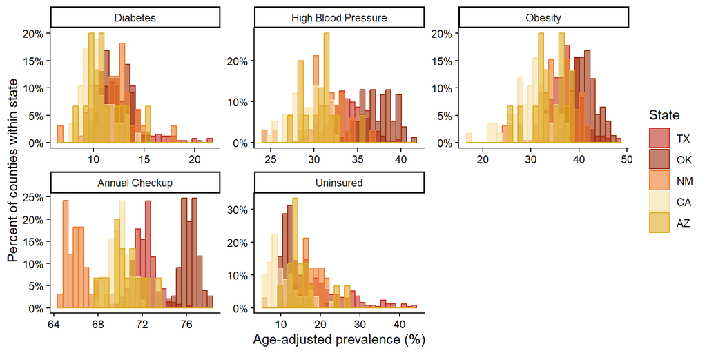

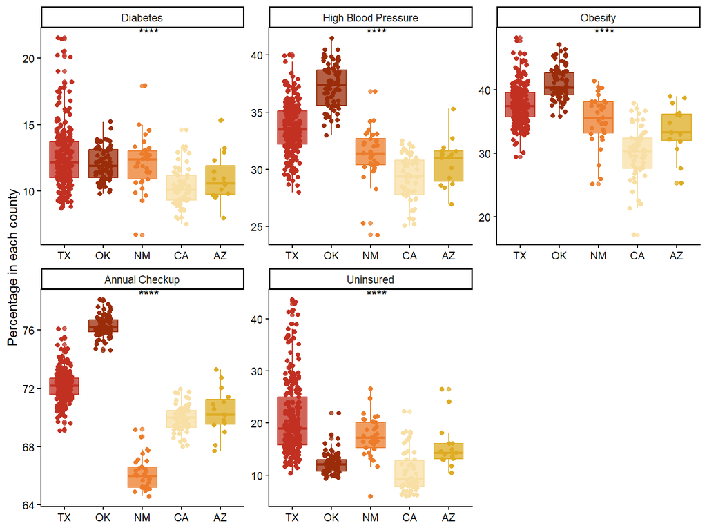

Significant Pairwise State Comparisons

| Measure | State 1 | State 2 | Z Statistic | Adjusted P-Value |
| --- | --- | --- | --- | --- |
| Annual Checkup | CA | OK | 14.44 | 2.72 × 10<sup>−46</sup> |
| Annual Checkup | NM | OK | 14.48 | 1.63 × 10<sup>−46</sup> |
| Annual Checkup | OK | TX | −10.34 | 3.54 × 10<sup>−24</sup> |
| High Blood Pressure | CA | OK | 14.28 | 2.96 × 10<sup>−45</sup> |
| Obesity | CA | OK | 13.31 | 1.96 × 10<sup>−39</sup> |
| Uninsured | CA | TX | 11.30 | 1.27 × 10<sup>−28</sup> |
| Uninsured | OK | TX | 11.28 | 1.51 × 10<sup>−28</sup> |

Table 2. P-values and Z-statistics are shown for state-by-state pairwise comparisons. Only comparisons with an adjusted *p*-value < 0.05 and an absolute Z-statistic greater than 10 are displayed.

Median County Prevalence by State

| Measure | AZ | CA | NM | OK | TX |
| --- | --- | --- | --- | --- | --- |
| Annual Checkup | 70.2% | 70.0% | 66.0% | 76.2% | 72.2% |
| Diabetes | 10.6% | 10.1% | 12.4% | 11.9% | 12.2% |
| High Blood Pressure | 31.0% | 29.4% | 31.4% | 37.4% | 33.5% |
| Obesity | 33.3% | 30.4% | 35.6% | 40.4% | 37.5% |
| Uninsured | 14.3% | 9.2% | 17.2% | 12.1% | 19.0% |

Table 3. Values represent the median county-level age-adjusted prevalence for each measure.

#### #2: Is there a relationship between preventive care access and chronic disease burden?

Preventive care access showed a clear but uneven relationship with chronic disease burden. Lack of health insurance was positively correlated with all three burden measures, with diabetes showing the strongest relationship in the analysis (ρ = 0.75, p < .001). Counties with higher uninsured rates consistently showed higher diabetes prevalence. Obesity (ρ = 0.40, p < .001) and high blood pressure (ρ = 0.25, p < .001) also showed statistically significant, positive relationships with uninsured rates, albiet with weaker correlation.

High blood pressure (ρ = 0.53, p < .001) and obesity (ρ = 0.39, p < .001) were both positively correlated with checkup rates. Counties where more residents visited a doctor annually showed higher, not lower, prevalence of these conditions. Diabetes showed no significant relationship with checkup rate (ρ = −0.05, p = .33). Because these measures rely on self-reported, diagnosed conditions rather than direct clinical measurement, this pattern likely reflects a detection effect: more frequent checkups increase the likelihood that an existing condition is identified and recorded. This suggests that uninsured rate is a more direct proxy for care access in this dataset, while checkup rate is better understood as a proxy for diagnostic detection. Figure 3 illustrates the six relationships directly.

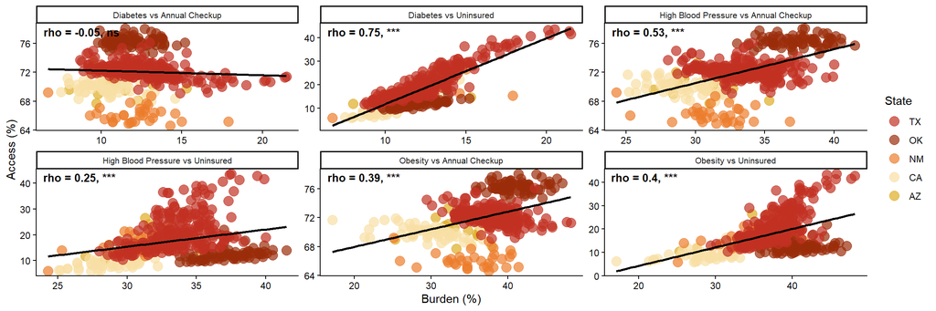

Figure 3. Uninsured rate shows a consistent positive relationship with chronic disease burden, strongest for diabetes; checkup rate’s relationship is inconsistent and, for diabetes, statistically null.

#### #3: How does this access-burden relationship vary between states?

First, the relationship between uninsured rates and various burdens were evaluated within each state. The diabetes-uninsured relationship was significant and positively correlated across every state, though its strength varied: ranging from ρ = 0.63 in Oklahoma to ρ = 0.89 in Texas, with California (ρ = 0.88), Arizona (ρ = 0.70), and New Mexico (ρ = 0.67) falling between (Figure 4, Table 4). The obesity-uninsured relationship was also significant in every state, with variability in strength, ranging from ρ = 0.29 in Oklahoma to ρ = 0.72 in Texas. The high blood pressure-uninsured relationship was directionally consistent across all five states but did not reach statistical significance in Arizona (ρ = 0.50, p = .06). This nay be due to Arizona’s small county count (n = 15) rather than a true absence of relationship, given that the direction and magnitude were consistent with those of the other sampled states.

These results are summarized in Figure 4 below.

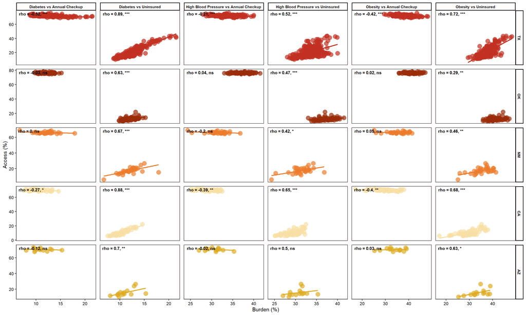

Strong Within-State Correlations

| Measure Pair | Spearman's ρ | P-Value |
| --- | --- | --- |
| AZ |  |  |
| Diabetes vs Uninsured | 0.70 | 0.003 |
| Obesity vs Uninsured | 0.63 | 0.013 |
| CA |  |  |
| Diabetes vs Uninsured | 0.88 | <0.001 |
| Obesity vs Uninsured | 0.68 | <0.001 |
| High Blood Pressure vs Uninsured | 0.65 | <0.001 |
| NM |  |  |
| Diabetes vs Uninsured | 0.67 | <0.001 |
| Obesity vs Uninsured | 0.46 | 0.007 |
| High Blood Pressure vs Uninsured | 0.42 | 0.015 |
| OK |  |  |
| Diabetes vs Uninsured | 0.63 | <0.001 |
| High Blood Pressure vs Uninsured | 0.47 | <0.001 |
| TX |  |  |
| Diabetes vs Uninsured | 0.89 | <0.001 |
| Obesity vs Uninsured | 0.72 | <0.001 |
| High Blood Pressure vs Uninsured | 0.52 | <0.001 |
| Diabetes vs Annual Checkup | −0.52 | <0.001 |
| Obesity vs Annual Checkup | −0.42 | <0.001 |

Table 4. Only statistically significant correlations (*p* < 0.05) with an absolute Spearman correlation of at least 0.40 are shown.

#### #4: How do counties associated with major metropolitan areas compare to their rural areas within the same state?

Rural counties showed higher uninsured rates than their state’s urban counties in four of five states: California (9.7% rural vs. 8.8% urban), Arizona (14.6% vs. 13.1%), New Mexico (17.5% vs. 14.2%), and most notably Texas (19.0% vs. 14.5%, a 4.6 percentage-point gap, the largest urban-rural insurance gap observed). Oklahoma was the exception, with rural and urban insurance rates nearly identical (12.1% vs. 12.2%) (Figure 5).

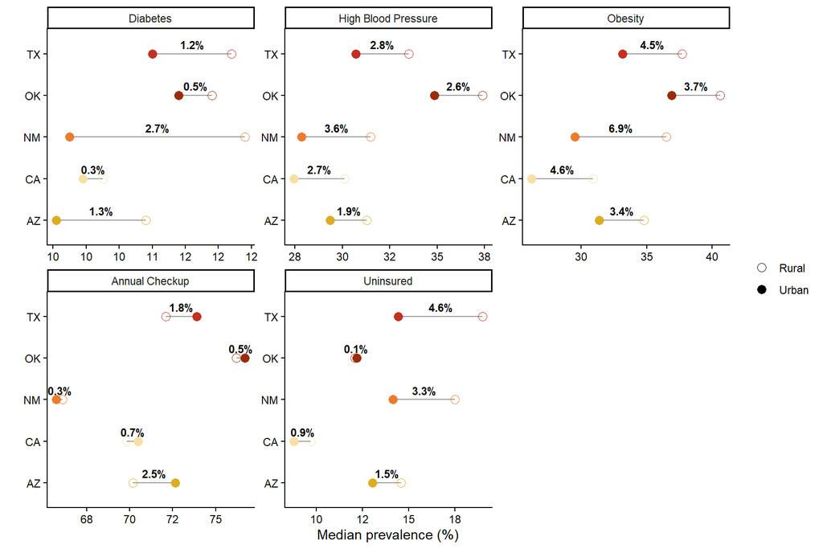

This urban-rural insurance gap generally tracked with the disease burden gap in the same direction: rural counties also showed higher obesity, diabetes, and high blood pressure prevalence than urban counties in nearly every state, with New Mexico showing the widest rural-urban obesity gap observed anywhere in the dataset (36.5% rural vs. 29.6% urban, a 6.95 percentage-point difference). Oklahoma again stood apart, showing comparatively small urban-rural gaps across most measures despite having the highest statewide burden overall. This indicates that Oklahoma’s chronic disease burden is elevated broadly across both urban and rural counties, rather than concentrated in one or the other.

These results suggest that New Mexico and Texas are the states where rural-urban disparities in access and burden are most pronounced, while Oklahoma’s elevated burden is potentially a statewide pattern not explained by the urban-rural divide.

However, not all identified gaps were found to be statistically significant. Figure 6 confirms which of these rural-urban gaps reach statistical significance. Notably, most of Oklahoma’s gaps do not reach significance despite Oklahoma’s high overall burden. Only in Texas were all five measures significantly different between rural and urban counties.

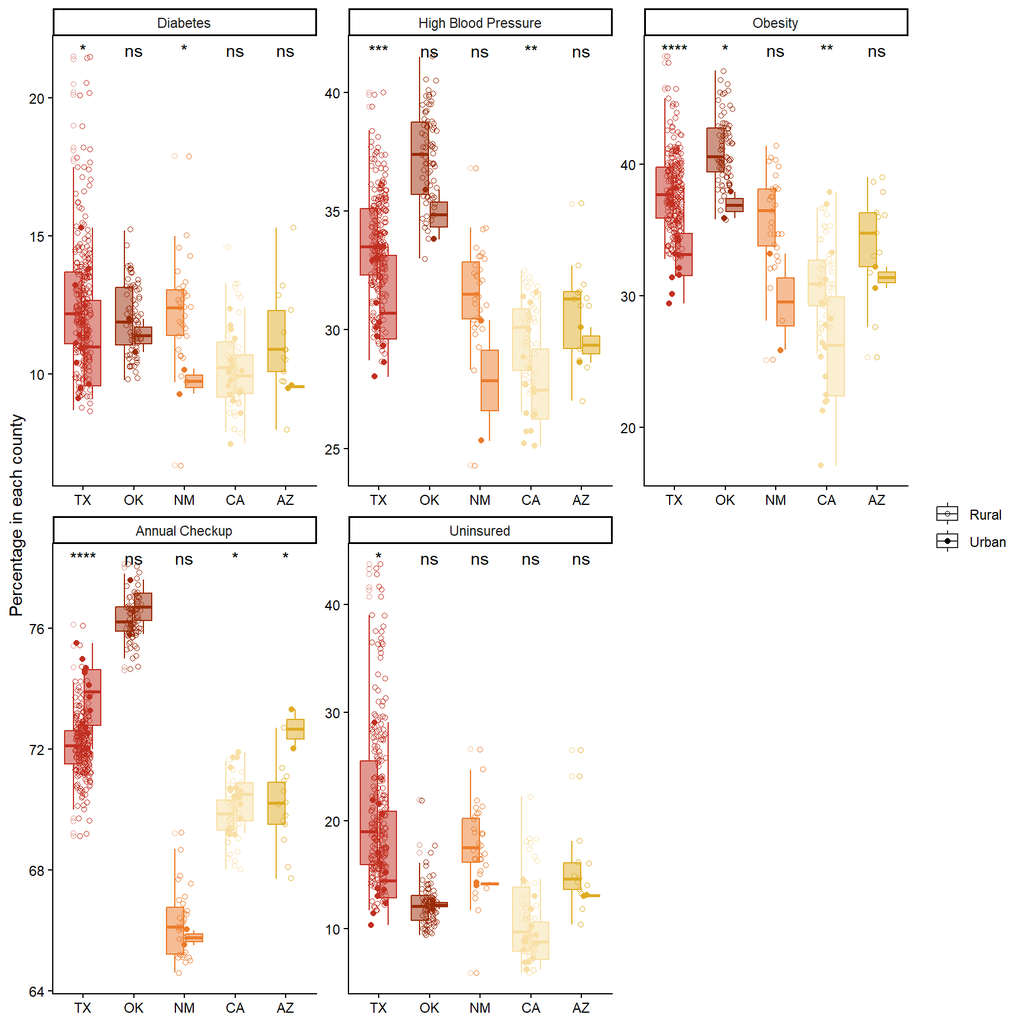

Figure 6. Texas is the only state where rural-urban differences reach statistical significance across all five measures.

**Note: as flagged in Methods, urban county counts for Arizona, New Mexico, and Oklahoma are small (n = 2 each), so these states’ urban-category comparisons should be treated as indicative rather than statistically robust.**

### Conclusions & Recommendations

This analysis points to insurance coverage, rather than checkup frequency, as the more reliable lever for addressing chronic disease burden in the Southwest. The relationship between uninsured rate and diabetes prevalence was not only the strongest observed in this analysis but also the most consistent, being statistically significant across all five states. This consistency makes expanding insurance access a stronger, better-supported priority than checkup-based outreach, particularly for diabetes, where the detection-driven checkup relationship offered no significant signal at all.

Texas and New Mexico warrant particular attention for rural outreach. These states show the widest gaps between rural and urban counties in insurance coverage, and show correspondingly wide rural-urban gaps in chronic disease burden. Rural-targeted insurance enrollment efforts may offer the clearest opportunity for impact in Texas and New Mexico.

Oklahoma presents a different pattern and requires a different response. Its elevated chronic disease burden appears broadly across both urban and rural counties rather than concentrated in one, suggesting statewide programming may be more appropriate than a rural targeted approach.

As these suggested interventions are based on modeled prevalence data from surveys, they are best used to identify where to prioritize further investigation and resource planning, not as the sole evidence baseline for future actions.

### Appendix

The following tables provide additional statistical detail underlying the tests conducted in this analysis.

| Measure | p_value |
| --- | --- |
| Annual Checkup | 1.067356e-67 |
| Diabetes | 3.842363e-13 |
| High Blood Pressure | 4.057582e-50 |
| Obesity | 6.304770e-41 |
| Uninsured | 4.966988e-45 |

Supplementary Table 1: Table of measure and p-value; for data shown in Figure 2.

| Measure | Effect Size | Magnitude |
| --- | --- | --- |
| Annual Checkup | 0.7298606 | large |
| Diabetes | 0.1396132 | moderate |
| High Blood Pressure | 0.5406593 | large |
| Obesity | 0.4415369 | large |
| Uninsured | 0.4858134 | large |

Supplementary Table 2:Effect size and magnitude for data shown in Figure 2

| State | Measure | Rural | Urban | Difference |
| --- | --- | --- | --- | --- |
| AZ | Annual Checkup | 70.20 | 72.65 | 2.45 |
| AZ | Diabetes | 10.90 | 9.55 | -1.35 |
| AZ | High Blood Pressure | 31.30 | 29.35 | -1.95 |
| AZ | Obesity | 34.80 | 31.40 | -3.40 |
| AZ | Uninsured | 14.60 | 13.05 | -1.55 |
| CA | Annual Checkup | 69.85 | 70.50 | 0.65 |
| CA | Diabetes | 10.25 | 9.95 | -0.30 |
| CA | High Blood Pressure | 30.10 | 27.45 | -2.65 |
| CA | Obesity | 30.90 | 26.25 | -4.65 |
| CA | Uninsured | 9.70 | 8.80 | -0.90 |
| NM | Annual Checkup | 66.10 | 65.75 | -0.35 |
| NM | Diabetes | 12.40 | 9.75 | -2.65 |
| NM | High Blood Pressure | 31.50 | 27.85 | -3.65 |
| NM | Obesity | 36.50 | 29.55 | -6.95 |
| NM | Uninsured | 17.50 | 14.15 | -3.35 |
| OK | Annual Checkup | 76.20 | 76.70 | 0.50 |
| OK | Diabetes | 11.90 | 11.40 | -0.50 |
| OK | High Blood Pressure | 37.40 | 34.85 | -2.55 |
| OK | Obesity | 40.60 | 36.90 | -3.70 |
| OK | Uninsured | 12.10 | 12.20 | 0.10 |
| TX | Annual Checkup | 72.10 | 73.90 | 1.80 |
| TX | Diabetes | 12.20 | 11.00 | -1.20 |
| TX | High Blood Pressure | 33.50 | 30.70 | -2.80 |
| TX | Obesity | 37.70 | 33.15 | -4.55 |
| TX | Uninsured | 19.00 | 14.45 | -4.55 |

Supplementary Table 3: Detailed values associated with figure 5